# Classification

Author

Nicole Rodgers

Published

February 24, 2025

**Abstract:**

This is a technical blog post of **both** an HTML file *and* [.qmd file](https://raw.githubusercontent.com/cd-public/D505/refs/heads/master/hws/src/classify.qmd) hosted on GitHub pages.

# 1. Setup

**Step Up Code:**

```r
sh <- suppressPackageStartupMessages
sh(library(tidyverse))
sh(library(caret))
sh(library(naivebayes))
sh(library(tidytext))
sh(library(SnowballC))
sh(library(pROC))
sh(library(glmnet))
data(stop_words)
wine <- readRDS(gzcon(url("https://github.com/cd-public/D505/raw/master/dat/pinot.rds")))
names(wine)[names(wine) == 'id'] = 'id'
```

# 2. Logistic Concepts

Why do we call it Logistic Regression even though we are using the technique for classification?

> TODO: This method does not Classify a wine by predicting a province, it gives us the Probabability that it comes from a particular province, which we can then plot against a 1:1 Regression.

# 3. Modeling

We train a logistic regression algorithm to classify a whether a wine comes from Marlborough using:

```r
# Feature engineering
desc_to_words <- function(df, omits) {
  df %>%
    unnest_tokens(word, description) %>%
    anti_join(stop_words) %>% # get rid of stop words
    filter(!(word %in% omits))
}
words <- desc_to_words(wine, c("wine","pinot","vineyard"))
words_to_stems <- function(df) {
  df %>%
    mutate(word = wordStem(word))
}
stems <- words_to_stems(words)
filter_by_count <- function(df, j) {
  df %>%
    count(id, word) %>%
    group_by(id) %>% mutate(exists = (n>0)) %>% ungroup %>%
    group_by(word) %>%
    mutate(total = sum(n)) %>%
    filter(total > j)
}
pivoter <- function(words, df) {
  words %>%
    pivot_wider(id_cols = id, names_from = word, values_from = exists, values_fill = list(exists=0)) %>%
    right_join(select(df,id,province)) %>%
    drop_na() %>%
    select(-id)
}
wine_words <- function(df, j, stem) {
  words <- desc_to_words(df, c("wine","pinot","vineyard"))
  if (stem) {
    words <- words_to_stems(words)
  }
  words <- filter_by_count(words, j)
  pivoter(words, df)
}
wino <- wine_words(wine, 1000, F)
wino <- wino %>%
  mutate(marl = factor(province=="Marlborough")) %>%
  select(-province)

# Regression
wine_index <- createDataPartition(wino$marl, p = 0.80, list = FALSE)
train <- wino[ wine_index, ]
test <- wino[-wine_index, ]
table(train$marl)
```

```
FALSE  TRUE
 6463   180
```

```r
control = trainControl(method = "cv", number = 5)
get_fit <- function(df) {
  train(marl ~ .,
        data = df,
        trControl = control,
        method = "glm",
        family = "binomial",
        maxit = 5)
}
fit <- get_fit(train)
fit
```

```
Generalized Linear Model

6643 samples
  22 predictor
   2 classes: 'FALSE', 'TRUE'

No pre-processing
Resampling: Cross-Validated (5 fold)
Summary of sample sizes: 5315, 5315, 5314, 5314, 5314
Resampling results:

  Accuracy   Kappa
  0.9759142  0.2642527
```

# 4. Binary vs Other Classification

What is the difference between determining some form of classification through logistic regression versus methods like $K$-NN and Naive Bayes which performed classifications.

> TODO: A Regression will give you the likelihood that the prediction is correct, which better allows you to analyze the accuracy of your model. A Classification will give you a definitive answer, which be could correct because of a good model or a lucky guess.

# 5. ROC Curves

We can display an ROC for the model to explain your model’s quality.

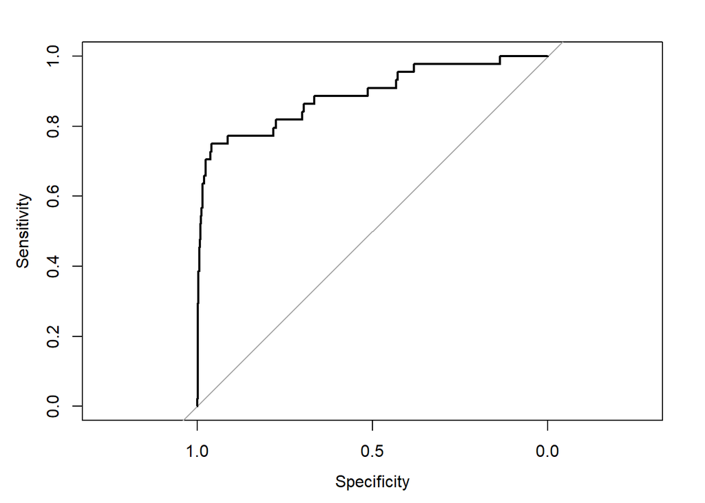

```r
prob <- predict(fit, newdata = test, type = "prob")[,2]
myRoc <- roc(test$marl, prob)
plot(myRoc)
```

```r
auc(myRoc)
```

```
Area under the curve: 0.8894
```

> TODO: The AUC of >0.8 suggests high accuracy and an effective model.